# Homework 4: Tasks and States

In this exercise, you will practice writing a mechatronics program directly from task and state diagrams. The diagrams are shown below.

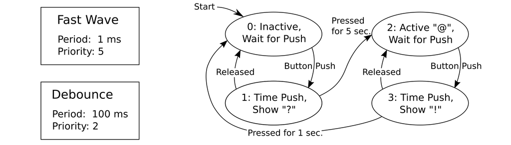

The Fast Wave task should be a copy of your fast square wave task from Homework 2, producing a 500 Hz output on GPIO pin 12.  
The Debounce task will be new.

### A Pushbutton

You will need a pushbutton or similar part which connects GPIO pin 13 to ground when pressed. If you have a button, that’s fine; if not, you can use a through-hole resistor of 1000 ohms or less or even a piece of wire. Connect one end of the resistor or wire to GPIO 13. To “push” the button, tap the other end on the metal body of the USB jack or another ground.

### The New Task

Task Debounce will be used to read the real or simulated pushbutton. This task should run every 100 ms (approximately is fine). This task should implement the state machine shown above. The idea is that the user has to hold down the button for 5 seconds to activate a device; when the device is active, the program prints an `@` sign 10 times per second. When inactive, the program prints nothing. The program prints `?` 10 times per second when the user is holding down the button *to activate* the device, and it prints `!` 10 times per second when the user holds down the button *to deactiate* the device. Therefore, if the user holds down the button for 6 seconds, the printout should show:

```
???????????????????????????????????????????????????????@@@@@@@@@@
```

and keep printing `@` signs until the user holds down the button for at least 1 second, which will show:

```
!!!!!!!!!!!????
```

The extra `?` characters are printed because the user didn’t release the button after exactly one second, so the machine jumped from State 3 to State 0, then immediately into State 1. Releasing the button after only a few `?` characters have appeared leaves the program in State 0.

### Hints

- You should name the pins as `const uint8_t BUTTON_PIN = 13;` or equivalent.
- It’s easiest to use a counter to measure how long a button has been pressed, because every time the button task runs, another 100 ms have elapsed. Make sure to reset the counter to zero every time the task changes to a new state.
- The code must be commented as usual, with Doxygen style comment blocks at the beginning of every file and above every function.
- The GPIO pin for the button requires a pullup resistor to function. You could add a 10 kΩ resistor from the pin to 3.3V, but it’s easier to use the internal pullup resistor inside the microcontroller with code like the following:  
  `pinMode (A_PIN, INPUT_PULLUP);`
- Your program will be checked to ensure that while the debouncing task is running, the 500 Hz square wave continues to appear without interruption.

### Deliverables

Before you submit your assignment, move Task Debounce into its own files called `task_debounce.h` and `task_debounce.cpp`. Leave the Fast Wave task inside `main.cpp`. Put these three files *and no other files* into a `.zip` archive file. The files should **not** be in a subdirectory within the `.zip` archive. Submit your archive to this assignment.